# A madridi Airbnb kínálata

# 6 Június-Szeptember becsült foglalási arány kiszámítása

```r
#Első lépés az értékelések száma apartmanonként
#Bökkenő: nem egyértelműen eldönthetőhogy egy hó eleji értékelés arra a hónapra vagy a korábbira vonatkozott. Hogy mindegyik hónapot külön tudjam vizsgálni újabb egyszerűsítéssel éltem. Az előző havi értékeléseknek "1 hét haladékot" számoltam, szeptember esetében pedig 2-t.

total <- total[, month:= ifelse(date>="2019-09-07", "September",
                                ifelse(date>="2019-08-07", "August",
                                       ifelse(date>="2019-07-07", "July", "June")))]

#Ez alapj összesíthetjük egy szállást az adott hónapban hányszor foglaltak ki. Az Airbnb legfrisebb becslése 2015-ös amiben az átlagos tartózkodást 4,6 napra becsülték. Az Inside Airbnb csapata ismeretlen friss adat esetén 3 napos tartózkodással becsül. Mielőtt meghatároztam volna azt a számot amivel én becslem a napok számát, kíváncsi voltam a foglalási arányok eloszlására.
min(total$date)
```

```
## [1] "2019-06-06"
```

```r
hiba <- subset(total, total$last_review<="2019-06-01")
summary(hiba)
```

```
##        id               date              host_id          neighbourhood_group
##  Min.   :   24805   Length:1852        Min.   :    31622   Length:1852
##  1st Qu.:22649751   Class :character   1st Qu.: 27526991   Class :character
##  Median :35341797   Mode  :character   Median :107141654   Mode  :character
##  Mean   :29740285                      Mean   :130509965
##  3rd Qu.:38007998                      3rd Qu.:241652103
##  Max.   :38730025                      Max.   :295894160
##
##   room_type             price         number_of_reviews reviews_per_month
##  Length:1852        Min.   :  10.00   Min.   :  0.00    Min.   :0.0200
##  Class :character   1st Qu.:  35.00   1st Qu.:  0.00    1st Qu.:0.2400
##  Mode  :character   Median :  60.00   Median :  0.00    Median :0.4600
##                     Mean   :  97.77   Mean   :  7.38    Mean   :0.6359
##                     3rd Qu.:  90.00   3rd Qu.:  6.00    3rd Qu.:0.9200
##                     Max.   :9999.00   Max.   :226.00    Max.   :4.7600
##                                                         NA's   :1159
##  availability_365 host_response_time host_response_rate host_is_superhost
##  Min.   :  0.0    Length:1852        Length:1852        Length:1852
##  1st Qu.: 69.0    Class :character   Class :character   Class :character
##  Median :164.0    Mode  :character   Mode  :character   Mode  :character
##  Mean   :182.4
##  3rd Qu.:326.0
##  Max.   :365.0
##
##  host_listings_count host_has_profile_pic host_identity_verified
##  Min.   :  0.00      Length:1852          Length:1852
##  1st Qu.:  1.00      Class :character     Class :character
##  Median :  2.00      Mode  :character     Mode  :character
##  Mean   : 12.45
##  3rd Qu.:  5.00
##  Max.   :525.00
##
##  is_location_exact  property_type       accommodates      bathrooms
##  Length:1852        Length:1852        Min.   : 1.000   Min.   : 0.000
##  Class :character   Class :character   1st Qu.: 2.000   1st Qu.: 1.000
##  Mode  :character   Mode  :character   Median : 2.000   Median : 1.000
##                                        Mean   : 3.117   Mean   : 1.276
##                                        3rd Qu.: 4.000   3rd Qu.: 1.500
##                                        Max.   :16.000   Max.   :11.500
##
```

[output cut: 41 more lines]

```
##  Length:1852        Length:1852         Length:1852
##  Class :character   Class :character    Class :character
##  Mode  :character   Mode  :character    Mode  :character
##
##
##
##
##  availability_30    month
##  Min.   : 0.00   Length:1852
##  1st Qu.: 5.00   Class :character
##  Median :12.00   Mode  :character
##  Mean   :12.41
##  3rd Qu.:19.00
##  Max.   :30.00
##
```

```r
#Kíváncsi voltam csúszott-e hiba a táblázatba ezért kikértem azokat a szállásokat ahol az utolsó értékelés június 1. előtt volt. Meglepő módon kilistázott közel 2000 sort, de mindegyiknél volt friss értékelés.
kable(hiba[1:5])
```

| id | date | host_id | neighbourhood_group | room_type | price | number_of_reviews | reviews_per_month | availability_365 | host_response_time | host_response_rate | host_is_superhost | host_listings_count | host_has_profile_pic | host_identity_verified | is_location_exact | property_type | accommodates | bathrooms | bedrooms | beds | bed_type | weekly_price | monthly_price | security_deposit | cleaning_fee | maximum_nights | has_availability | last_review | review_scores_rating | … |
| --- | --- | --- | --- | --- | --- | --- | --- | --- | --- | --- | --- | --- | --- | --- | --- | --- | --- | --- | --- | --- | --- | --- | --- | --- | --- | --- | --- | --- | --- | --- |
| 24805 | 2019-10-02 | 101471 | Centro | Entire home/apt | 80 | 2 | 0.03 | 354 | within a day | 100% | f | 1 | t | t | t | Apartment | 3 | 1 | 0 | 1 | Real Bed | $450.00 | $1,200.00 | $200.00 | $30.00 | 730 | t | 2017-07-03 | 100 | … |
| 59923 | 2019-09-22 | 288380 | Centro | Private room | 40 | 14 | 0.14 | 363 | within a few hours | 100% | f | 1 | t | f | t | Guest suite | 1 | 1 | 1 | 1 | Real Bed | $245.00 |  |  |  | 30 | t | 2018-12-09 | 98 | … |
| 59923 | 2019-09-29 | 288380 | Centro | Private room | 40 | 14 | 0.14 | 363 | within a few hours | 100% | f | 1 | t | f | t | Guest suite | 1 | 1 | 1 | 1 | Real Bed | $245.00 |  |  |  | 30 | t | 2018-12-09 | 98 | … |
| 59923 | 2019-10-05 | 288380 | Centro | Private room | 40 | 14 | 0.14 | 363 | within a few hours | 100% | f | 1 | t | f | t | Guest suite | 1 | 1 | 1 | 1 | Real Bed | $245.00 |  |  |  | 30 | t | 2018-12-09 | 98 | … |
| 70310 | 2019-10-11 | 353738 | Centro | Entire home/apt | 70 | 18 | 0.18 | 343 | within an hour | 100% | f | 5 | t | t | t | Apartment | 4 | 1 | 1 | 3 | Real Bed | $399.00 | $1,302.00 | $500.00 | $50.00 | 360 | t | 2019-05-19 | 82 | … |

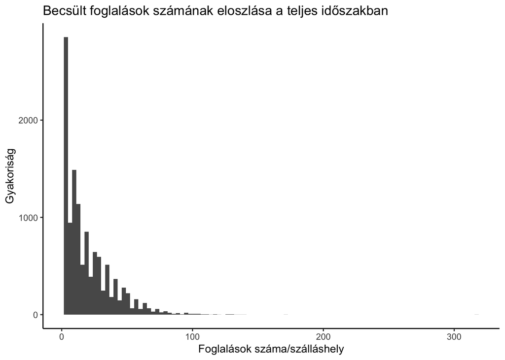

```r
#Number of bookings per month

total <- total[, total_bookings:= (count=.N), by=id]
#50%-os szabálynál
total <- total[, total_bookings:= (total_bookings*2), by=id]

total <- total[, monthly_bookings:=(count=.N), by=.(id, month)]
total <- total[, monthly_bookings:=(monthly_bookings*2), by=.(id, month)]

bookings <- total[, total_bookings, by=id]
bookings <- unique(bookings)

hist <- ggplot(bookings, aes(total_bookings))+geom_histogram(bins=100)+theme_classic()+ggtitle("Becsült foglalások számának eloszlása a teljes időszakban") + xlab("Foglalások száma/szálláshely") + ylab("Gyakoriság")
hist
```

```r
summary(bookings$total_bookings)
```

```
##    Min. 1st Qu.  Median    Mean 3rd Qu.    Max.
##    2.00    6.00   14.00   19.53   28.00  316.00
```

4 hónap alatt kicsit sok 316 foglalás - és fizikailag lehetetlen. Nézzük meg a havi foglalásokat

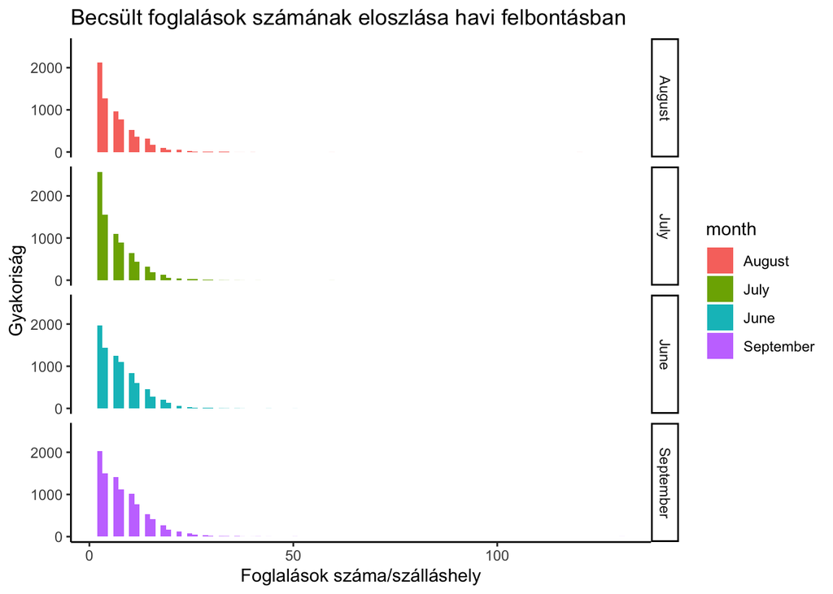

```r
bookings_monthly <- total[, c("id","monthly_bookings", "month")]
bookings_monthly <- unique(bookings_monthly)

hist_2 <-ggplot(bookings_monthly, aes(monthly_bookings, fill=month))+geom_histogram(bins=100)+theme_classic()+ggtitle("Becsült foglalások számának eloszlása havi felbontásban") + xlab("Foglalások száma/szálláshely") + ylab("Gyakoriság")+facet_grid(rows=vars(month))
hist_2
```

```r
august <- bookings_monthly[ month=="August"]
summary(august)
```

```
##        id           monthly_bookings     month
##  Min.   :    6369   Min.   :  2.000   Length:6800
##  1st Qu.:15562674   1st Qu.:  2.000   Class :character
##  Median :23350278   Median :  6.000   Mode  :character
##  Mean   :22498718   Mean   :  6.565
##  3rd Qu.:31480291   3rd Qu.:  8.000
##  Max.   :38236520   Max.   :120.000
```

Következő lépés az outlierek “eltüntetése”.

1. lépés: az 50%-os rátát közelítettem az Airbnb 72%-hoz, így tegyük fel, hogy 3-ból 2 ember hagy értékelést. A szorzó így 2-ről 1,5-re módosulna. Sajnos az R nem tudta kezelni a törteket (illetve én nem tudtam beállítani, hogy hatékonyan kezelje) így maradtam a 2-es szorzónál.

Mivel eddig foglalásokról volt szó (1 értékelés=2 foglalás), a napokkal egyéltalán nem is foglalkoztunk.

*Ezen a ponton kissé kezdett bonyolódni a feladat és a becslés egyre jobban torzult, ezért nem a napokra fókuszáltam, hanem a havi foglalások számára.*

Meg kellett becsülni egy keretet ami közelíthet a valósághoz. Első körben visszaállítottam az értékelési rátát 100%-ra, majd beállítottam egy havi maximum 12 foglalásos limitet. Ez átlag 2 éjszakás tartózkodás mellett is több mint havi 70%-os kihasználtságot jelent egy-egy szállás esetén.

```r
total <- total[, total_bookings:= (count=.N), by=id]
total <- total[, monthly_bookings:=(count=.N), by=.(id, month)]

outlier <- subset(total, total$monthly_bookings> 12)
nrow(outlier)
```

```
## [1] 4687
```

```r
#Kevesebb mint 5000 sor esik ki

total <- subset(total, total$monthly_bookings< 13)
total <- total[, total_bookings:= (count=.N), by=id]


max(total$total_bookings)
```

```
## [1] 44
```

```r
max(total$monthly_bookings)
```

```
## [1] 12
```

Ismét a hisztogramok:

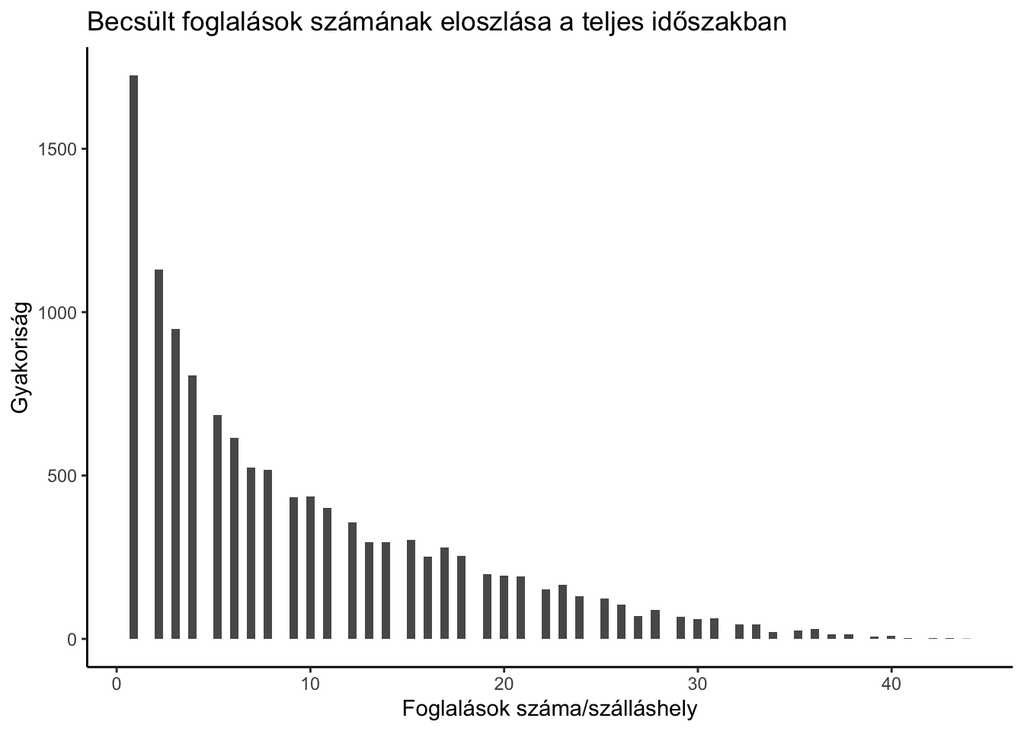

```r
bookings2 <- total [, c("id","total_bookings")]
bookings2 <- unique(bookings2)

hist <- ggplot(bookings2, aes(total_bookings))+geom_histogram(bins=100)+theme_classic()+ggtitle("Becsült foglalások számának eloszlása a teljes időszakban") + xlab("Foglalások száma/szálláshely") + ylab("Gyakoriság")
hist
```

```r
max(bookings2$total_bookings)
```

```
## [1] 44
```

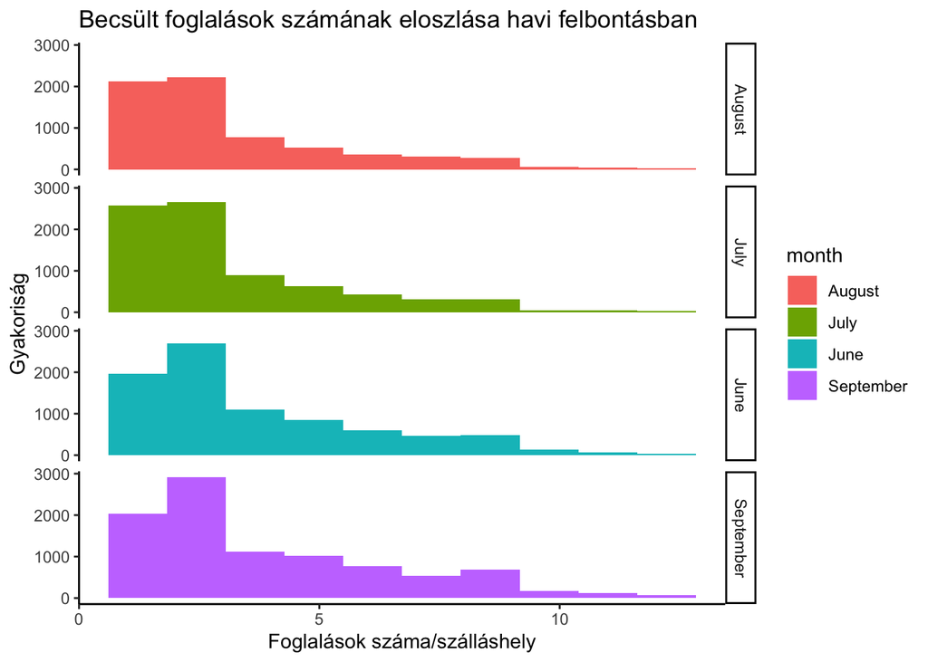

```r
bookings_monthly <- total[, c("id","monthly_bookings", "month")]
bookings_monthly <- unique(bookings_monthly)

hist_2 <-ggplot(bookings_monthly, aes(monthly_bookings, fill=month))+geom_histogram(bins=10)+theme_classic()+ggtitle("Becsült foglalások számának eloszlása havi felbontásban") + xlab("Foglalások száma/szálláshely") + ylab("Gyakoriság")+facet_grid(rows=vars(month))
hist_2
```